# Where are our Books? 2018 Sample Inventory of CUL Open Stacks

### EAST surveyed libraries that participated in their validation study about security practices

Sometime after completing it’s validation study, EAST conducted a survey of participating libraries to find out about the theft deterrence practices. 32 libraries responded. The library names are anonymized. Here are five, for example.

| library | tattletape_yes_no | validation_score |
| --- | --- | --- |
| anteater | Yes | 0.984 |
| armadillo | No | 0.948 |
| axolotl | No | 0.984 |
| buffalo | Yes | 0.935 |
| camel | Yes | 0.976 |

```
## # A tibble: 2 x 3
##   tattletape_yes_no     n  mean
##   <fct>             <int> <dbl>
## 1 No                   10 0.972
## 2 Yes                  22 0.974
```

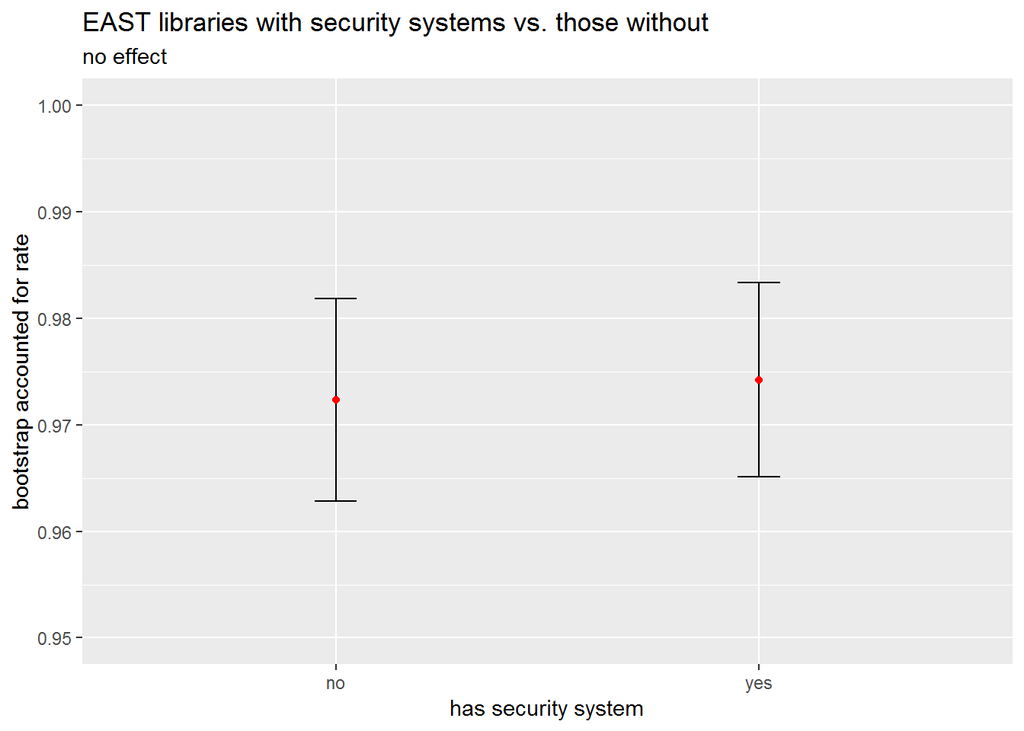

The validation study was useful in determining the availability of CUL materials in the open stacks; when patrons seek a monograph in the stacks, they are able to locate that item 96.4% of the time. This translates into a loss rate of 3.6% of materials in the open stacks.

We wish to decouple the idea that tattletapping is directly correlated to reducing lost items in the open stacks. As we have shown, there is minimal differences in the AF rate in libraries that tattletape versus libraries that do not tattletape.

## Recommendations

```r
df_orig_sample_summary <- read_csv("data/original_sample_draw/sum_comparison_all_vs_sample.csv")
df_orig_sample_summary <- clean_names(df_orig_sample_summary)
df_orig_sample_summary$location_group <- df_orig_sample_summary$perm_location_code
df_orig_sample_summary <- df_orig_sample_summary %>%
  filter(!perm_location_code == "vet")

df_unaf_estimates <- df_orig_sample_summary %>%
  select(perm_location_code, location_group, n_x) %>%
  rename(pop = n_x) %>%
  mutate(location_group = fct_recode(perm_location_code,
                                    "hlm" = "ilr",
                                    "hlm" = "hote",
                                    "hlm" = "jgsm",
                                    "asia" = "asia",
                                    "asia" = "was",
                                    "asia" = "ech",
                                    "asia" = "sasa")) %>%
  group_by(location_group) %>%
  summarise(pop_total = sum(pop)) %>%
  arrange(desc(pop_total))


# Need to add the proportions to the df_group_se df when it is created above.
# Below is wrong: Olin estiamtes for example should look like this:
# > 1648040 * .974
# [1] 1605191
# > 1648040 * (1 - .974)
# [1] 42849.04
# > 1648040 * (1 - .967)
# [1] 54385.32
# > 1648040 * (1 - .979)
# [1] 34608.84
# >


# df_unaf_estimates %>%
#   left_join(df_group_se, by = "location_group") %>%
#   select(-total, -num_missing) %>%
#   mutate(unafperc_hat = 1 - mean,
#          moe = se * 2,
#          unaf_hat = pop_total * unafperc_hat,
#          moenum = unaf_hat * moe,
#          cilow = unaf_hat - moenum,
#          cihigh = unaf_hat + moenum) %>%
#   select(-unafperc_hat, -moenum) %>%
#   mutate_at(vars(unaf_hat:cihigh), funs(round))
```

1. Where confidence intervals are widest, do more sampling in Cornell unit libraries to improve the accuracy of our estimates.
2. Create a statistical model that includes multiple variables to identify items with higher probability of being unaccounted for in the open stacks. A statistical model will inform us about the factors at play and help us to increase the availability of open stacks titles. This work is already underway.
3. Shift resoruces from seecurity stripping to stacks management. Security is only one variable that might account for differences in the percentage of items accounted for across different libraries, and from the empirical evidence we’ve gathered, it isn’t a variable with any predictive power here or across the EAST consortium. Therefore, we believe that a better investment is more support for open stacks control and management at units with lower accounted for rates.

# Appendix

## Data

```r
glimpse(df)
```

```
## Observations: 5,952
## Variables: 36
## $ barcode                      <chr> "31924062968908", "31924072130184...
## $ present_or_not               <fct> Present, Present, Present, Presen...
## $ location_code                <chr> "afr", "afr", "afr", "afr", "afr"...
## $ norm_cn                      <chr> "DT   32            R 61", "DT  3...
## $ call_nbr_display             <chr> "DT32 .R61", "DT328.M53 .H3613x 1...
## $ call_nbr_norm_item           <dbl> NA, NA, NA, NA, NA, NA, NA, NA, N...
## $ enumeration                  <chr> NA, NA, NA, NA, NA, NA, NA, "c.2"...
## $ item_control_nbr             <chr> "3723592", "4103508", "7620171", ...
## $ title                        <chr> "Death of Africa. By Peter Ritner...
## $ bib_rec_nbr                  <chr> "1968678", "2249095", "5689943", ...
## $ historical_charges           <dbl> 1, 0, 2, 0, 0, 10, 2, 0, 56, 1, 2...
## $ catalog_url                  <chr> "https://newcatalog.library.corne...
## $ worldcat_oclc_nbr            <chr> "412793", "59941146", "148569", "...
```

[output cut: 23 more lines]

## Bootstrap simulation

```r
library(infer)
set.seed(42)

replimit = 1000

p_hat <- df %>%
  summarise(stat = mean(is_accountedfor == "1")) %>%
  pull()

boot <- df %>%
  specify(response = is_accountedfor, success = "1") %>%
  generate(reps = replimit, type = "bootstrap") %>%
  calculate(stat = "prop")

se <- boot %>%
  summarize(sd(stat)) %>%
  pull()
```

# Bootstrap density comparison, EAST and CUL

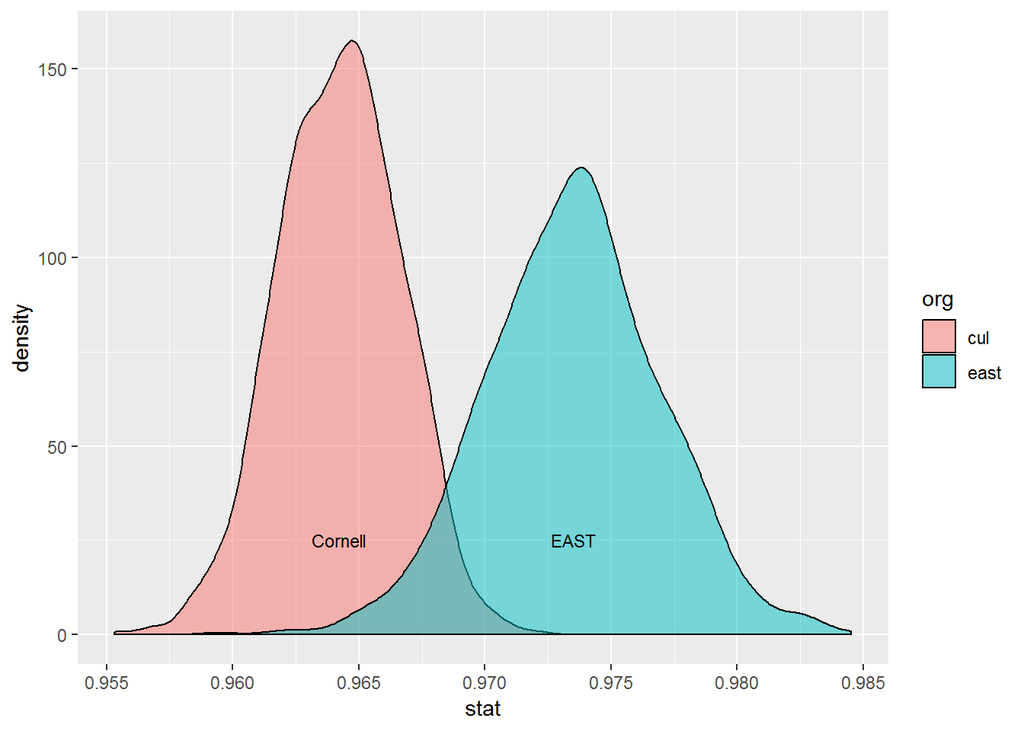